# Visualization slides

## 数据的可视化

- Matplotlib
  - 数据可视化、画图工具，风格受 Matlab 影响
  - 参考资料：Scipy Lecture Notes
- X Window System
  - 也被称为 X11
  - 图形显示的国际标准

### X11

- Server-client 架构
- Server 为显示图形提供服务
- Client 连接 X11 server，请求显示图形

### 配置环境

- Windows
  - 下载并安装 VcXsrv
  - VcXsrv 是使用 Visual Studio 编译的 X11
  - X11 server 运行在 Windows
    - X11 client 在 WSL 中
    - 两者通过本地网络接口通信
- MacOS
  - 默认无 X11 环境
  - 但是众多程序可以直接在 MacOS 的图形界面输出
- GNU/Linux
  - 默认有 X11 环境

[output not shown]

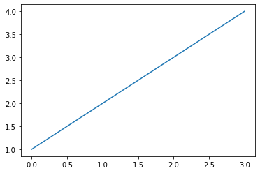

```python
from matplotlib import pyplot as plt

plt.plot([1,2,3,4])
plt.show()
```

```python
import numpy as np

t = np.linspace(-np.pi, np.pi, 100)
C, S = np.cos(t), np.sin(t)
```

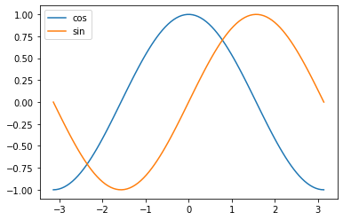

```python
plt.plot(t, C, label="cos")
plt.plot(t, S, label="sin")
plt.legend()
plt.show()
```

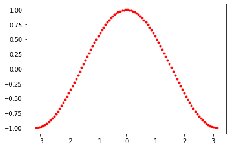

```python
plt.plot(t, C, "r.") # 改成红色的圆点
plt.show()
```

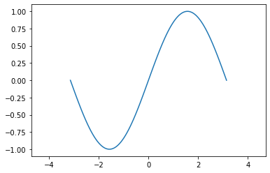

```python
plt.plot(t, S)
plt.xlim(t.min() * 1.5, t.max() * 1.5)
plt.show()
```

### 改变坐标轴的标识

- 弧度之下，以 $\pi$ 为单位更自然

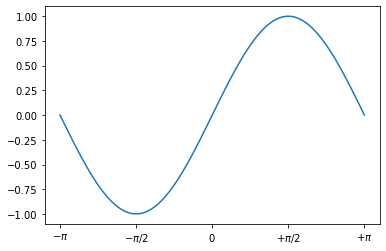

```python
plt.plot(t, S, label="sin")
plt.xticks([-np.pi, -np.pi/2, 0, np.pi/2, np.pi])
# 可以嵌入简单的 LaTeX
plt.xticks([-np.pi, -np.pi/2, 0, np.pi/2, np.pi],
          [r'$-\pi$', r'$-\pi/2$', r'$0$', r'$+\pi/2$', r'$+\pi$'])
plt.show()
```

### 子图

- 可以并排画图

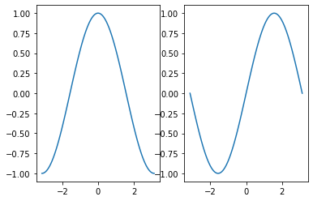

```python
plt.subplot(1, 2, 1)
plt.plot(t, C)
plt.subplot(1, 2, 2)
plt.plot(t, S)
plt.show()
```

### 散点图

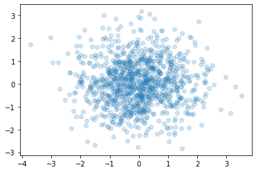

```python
n = 1024
X = np.random.normal(0, 1, n)
Y = np.random.normal(0, 1, n)

plt.scatter(X, Y, alpha=0.2)
plt.show()
```

### 柱状图

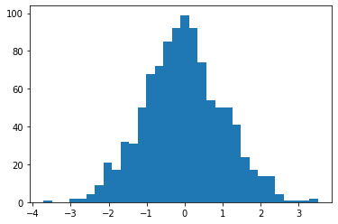

```python
plt.hist(X, bins=32)
plt.show()
```

## 多维元素的表现

－ 平铺表现简单的三维数据

```python
import numpy as np

img = np.arange(100).reshape(10, 10)
img
```

```
array([[ 0,  1,  2,  3,  4,  5,  6,  7,  8,  9],
       [10, 11, 12, 13, 14, 15, 16, 17, 18, 19],
       [20, 21, 22, 23, 24, 25, 26, 27, 28, 29],
       [30, 31, 32, 33, 34, 35, 36, 37, 38, 39],
       [40, 41, 42, 43, 44, 45, 46, 47, 48, 49],
       [50, 51, 52, 53, 54, 55, 56, 57, 58, 59],
       [60, 61, 62, 63, 64, 65, 66, 67, 68, 69],
       [70, 71, 72, 73, 74, 75, 76, 77, 78, 79],
       [80, 81, 82, 83, 84, 85, 86, 87, 88, 89],
       [90, 91, 92, 93, 94, 95, 96, 97, 98, 99]])
```

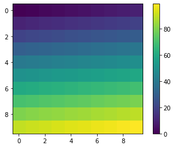

```python
plt.imshow(img)
plt.colorbar()
```

### 高斯分布的概率密度函数

```python
from scipy.stats import multivariate_normal

rv = multivariate_normal(mean=(0, 0), cov = ((1,0.5), (0.5,0.5)))
rv.pdf((0, 0))

x, y = np.mgrid[-1:1:.01, -1:1:.01]
```

```python
pos = np.dstack((x, y))
pos.shape

prob_density = rv.pdf(pos)
```

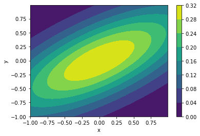

```python
plt.contourf(x, y, prob_density)
plt.colorbar()
plt.xlabel("x")
plt.ylabel("y")
plt.show()
```

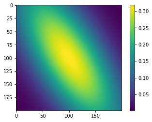

```python
plt.imshow(prob_density)
plt.colorbar()
```

### 画图的例子

https://matplotlib.org/3.1.1/gallery

- 看到需要的图，点进去可查看代码

```python
from scipy import special

x = np.linspace(0, 6, 100)
y_values = []
for n in range(0, 5):
    y_values.append(special.jv(n, x)) # 第一类 Bessel 函数
```

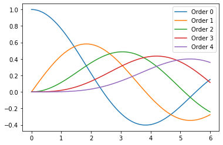

```python
for i, y in enumerate(y_values):
    plt.plot(x, y, label=f"Order {i}")
plt.legend()
plt.show()
```

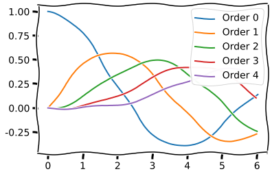

```python
for i, y in enumerate(y_values):
    plt.plot(x, y, label=f"Order {i}")
plt.legend()
plt.xkcd() # 漫图风格
plt.show()
```

## 画图原理

- 画图容易，但是画出有信息量，突出本质，令人赏心悦目的好图不易。
- 画图有艺术成分，没有一定之规，只能积累经验逐步提升
- 但有一些基本原理需要注意，掌握之后可以满足基本要求

参考：A layered grammar of graphics by Hadley Wickham

### 图是给人类看的

- 字要让人类看清
- 颜色对比在鲜明，易于人类辩认
- 要有可以让人类读懂的标识

### 连续量与离散量的表现

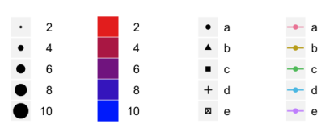

### 利用多个层次表现数据

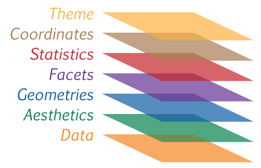